# Joshua Burrows Project 2

16 October 2020

- Bike Rentals on Tuesdays: Introduction
- Read in Data
  - Get Bikes Data
  - Factors
  - Filter by Day
- Exploratory Data Analysis
  - Quantitative Predictors
    - Correlations
    - Hour
    - Temperature
    - Felt Temperature
    - Humidity
    - Wind Speed
  - Categorical Predictors
    - Helper Function
    - Season
    - Year
    - Month
    - Holiday
    - Working Day
    - Weather Condition
- Train Models
  - Split Data
  - Non-Ensemble Tree
    - Training
      - Tree Models
      - Tuning Parameter
      - Formula
      - Create the Model
    - Model Information
  - Boosted Tree
    - Training
      - Boosted Tree Models
      - Tuning Paremeters
      - Create the Model
    - Model Information
  - Multiple Linear Regression
    - Training
      - Create the Model
- Test Models
- Best Model

# Bike Rentals on Tuesdays: Introduction

This document walks though the process of creating a model to predict hourly bike rentals on Tuesdays. I compared two models - a *non-ensemble tree* and a *boosted tree* - and picked the one that does better.

The data comes from the Capital bike sharing system, and it is available [here](https://archive.ics.uci.edu/ml/datasets/Bike+Sharing+Dataset). This data includes an hourly count of bike rentals for 2011 and 2012 as well as information about the weather and the time of year.

My models use the following predictor variables:

- *yr*: year (2011 or 2012)
- *mnth*: month
- *hr*: hour of the day
- *holiday*: whether the day is a holiday
- *weathersit*: weather condition
  - pleasant: clear, few clouds, partly cloudy
  - less pleasant: mist, mist + cloudy, mist + broken clouds, mist + few clouds
  - even less pleasant: light snow, light rain + scattered clouds, light rain + thunderstorm + scattered clouds
  - downright unpleasant: snow + fog, heavy rain + ice pallets + thunderstorm + mist
- *temp*: normalized temperature in celsius
- *hum*: normalized humidity
- *windspeed*: normalized wind speed

You can return to the homepage for this project by clicking [here](https://jkburrows.github.io/ST558-Project-2/). The github repo for this project is [here](https://github.com/JKBurrows/ST558-Project-2).

# Read in Data

## Get Bikes Data

Read in data.

```r
bikes <- read_csv(file = "hour.csv")

bikes %>% head() %>% kable()
```

| instant | dteday | season | yr | mnth | hr | holiday | weekday | workingday | weathersit | temp | atemp | hum | windspeed | casual | registered | cnt |
| --- | --- | --- | --- | --- | --- | --- | --- | --- | --- | --- | --- | --- | --- | --- | --- | --- |
| 1 | 2011-01-01 | 1 | 0 | 1 | 0 | 0 | 6 | 0 | 1 | 0.24 | 0.2879 | 0.81 | 0.0000 | 3 | 13 | 16 |
| 2 | 2011-01-01 | 1 | 0 | 1 | 1 | 0 | 6 | 0 | 1 | 0.22 | 0.2727 | 0.80 | 0.0000 | 8 | 32 | 40 |
| 3 | 2011-01-01 | 1 | 0 | 1 | 2 | 0 | 6 | 0 | 1 | 0.22 | 0.2727 | 0.80 | 0.0000 | 5 | 27 | 32 |
| 4 | 2011-01-01 | 1 | 0 | 1 | 3 | 0 | 6 | 0 | 1 | 0.24 | 0.2879 | 0.75 | 0.0000 | 3 | 10 | 13 |
| 5 | 2011-01-01 | 1 | 0 | 1 | 4 | 0 | 6 | 0 | 1 | 0.24 | 0.2879 | 0.75 | 0.0000 | 0 | 1 | 1 |
| 6 | 2011-01-01 | 1 | 0 | 1 | 5 | 0 | 6 | 0 | 2 | 0.24 | 0.2576 | 0.75 | 0.0896 | 0 | 1 | 1 |

## Factors

Convert categorical variables to factors.

```r
bikes$weekday <- as.factor(bikes$weekday)
levels(bikes$weekday) <- c("Sunday", "Monday", "Tuesday", "Wednesday", "Thursday", "Friday", "Saturday")

bikes$season <- as.factor(bikes$season)
levels(bikes$season) <- c("winter", "spring", "summer", "fall")

bikes$yr <- as.factor(bikes$yr)
levels(bikes$yr) <- c("2011", "2012")

bikes$mnth <- as.factor(bikes$mnth)
levels(bikes$mnth) <- c("jan", "feb", "mar", "apr", "may", "jun", "jul", "aug", "sep", "oct", "nov", "dec")

bikes$weathersit <- as.factor(bikes$weathersit)
levels(bikes$weathersit) <- c("pleasant", "less pleasant", "even less pleasant", "downright unpleasant")

bikes$holiday <- as.factor(bikes$holiday)
levels(bikes$holiday) <- c("no", "yes")

bikes$workingday <- as.factor(bikes$workingday)
levels(bikes$workingday) <- c("no", "yes")

bikes %>% head() %>% kable()
```

| instant | dteday | season | yr | mnth | hr | holiday | weekday | workingday | weathersit | temp | atemp | hum | windspeed | casual | registered | cnt |
| --- | --- | --- | --- | --- | --- | --- | --- | --- | --- | --- | --- | --- | --- | --- | --- | --- |
| 1 | 2011-01-01 | winter | 2011 | jan | 0 | no | Saturday | no | pleasant | 0.24 | 0.2879 | 0.81 | 0.0000 | 3 | 13 | 16 |
| 2 | 2011-01-01 | winter | 2011 | jan | 1 | no | Saturday | no | pleasant | 0.22 | 0.2727 | 0.80 | 0.0000 | 8 | 32 | 40 |
| 3 | 2011-01-01 | winter | 2011 | jan | 2 | no | Saturday | no | pleasant | 0.22 | 0.2727 | 0.80 | 0.0000 | 5 | 27 | 32 |
| 4 | 2011-01-01 | winter | 2011 | jan | 3 | no | Saturday | no | pleasant | 0.24 | 0.2879 | 0.75 | 0.0000 | 3 | 10 | 13 |
| 5 | 2011-01-01 | winter | 2011 | jan | 4 | no | Saturday | no | pleasant | 0.24 | 0.2879 | 0.75 | 0.0000 | 0 | 1 | 1 |
| 6 | 2011-01-01 | winter | 2011 | jan | 5 | no | Saturday | no | less pleasant | 0.24 | 0.2576 | 0.75 | 0.0896 | 0 | 1 | 1 |

## Filter by Day

Grab the data for Tuesday.

```r
dayData <- bikes %>% filter(weekday == params$day)

dayData %>% head() %>% kable()
```

| instant | dteday | season | yr | mnth | hr | holiday | weekday | workingday | weathersit | temp | atemp | hum | windspeed | casual | registered | cnt |
| --- | --- | --- | --- | --- | --- | --- | --- | --- | --- | --- | --- | --- | --- | --- | --- | --- |
| 70 | 2011-01-04 | winter | 2011 | jan | 0 | no | Tuesday | yes | pleasant | 0.16 | 0.1818 | 0.55 | 0.1045 | 0 | 5 | 5 |
| 71 | 2011-01-04 | winter | 2011 | jan | 1 | no | Tuesday | yes | pleasant | 0.16 | 0.1818 | 0.59 | 0.1045 | 0 | 2 | 2 |
| 72 | 2011-01-04 | winter | 2011 | jan | 2 | no | Tuesday | yes | pleasant | 0.14 | 0.1515 | 0.63 | 0.1343 | 0 | 1 | 1 |
| 73 | 2011-01-04 | winter | 2011 | jan | 4 | no | Tuesday | yes | pleasant | 0.14 | 0.1818 | 0.63 | 0.0896 | 0 | 2 | 2 |
| 74 | 2011-01-04 | winter | 2011 | jan | 5 | no | Tuesday | yes | pleasant | 0.12 | 0.1515 | 0.68 | 0.1045 | 0 | 4 | 4 |
| 75 | 2011-01-04 | winter | 2011 | jan | 6 | no | Tuesday | yes | pleasant | 0.12 | 0.1515 | 0.74 | 0.1045 | 0 | 36 | 36 |

# Exploratory Data Analysis

I started with a little bit of exploratory data analysis. The goal is to look at the relationships between the predictors and number of bike rentals.

## Quantitative Predictors

### Correlations

Visualize the strength of the relationships between the quantitative predictors.

Unsurprisingly, *atemp* and *temp* are strongly correlated. *atemp* represents the heat index, which is typically calculated using temperature and humidity. So it makes sense to either eliminate *atemp* from the model or keep *atemp* but eliminate *temp* and *hum*. I decided to eliminate *atemp*.

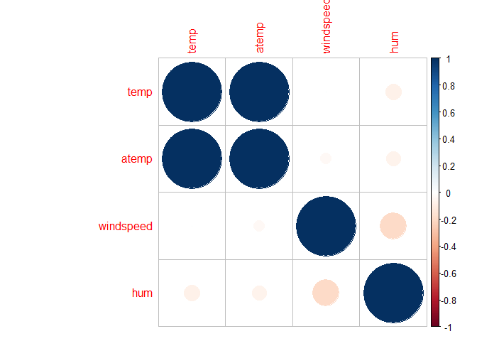

```r
corr <- dayData %>%
  select(temp, atemp, windspeed, hum) %>%
  cor()

corrplot(corr)
```

### Hour

Create a scatter plot to investigate the relationship between time of day and rentals on Tuesdays. Fit a line through the points to get a basic idea of how number or rentals changes with the time of day.

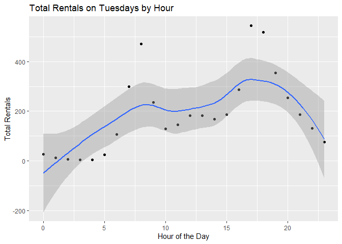

```r
avgRentals <- dayData %>%
  group_by(hr) %>%
  summarize(meanRentals = mean(cnt))

corrHour <- cor(avgRentals$hr, avgRentals$meanRentals)

ggplot(avgRentals, aes(x = hr, y = meanRentals)) +
  geom_point() +
  labs(title = paste0("Total Rentals on ", paste0(params$day, "s"), " by Hour"),
       x = "Hour of the Day",
       y = "Total Rentals") +
  geom_smooth()
```

The correlation between hour and average rentals is 0.491732.

Be careful, correlation measures straight line relationships, so if the plot above shows a curved relationship, correlation may not be a useful measure.

### Temperature

Create a scatter plot to investigate the relationship between temperature and average rentals on Tuesdays. Fit a line through the points to get a basic idea of average rentals changes with temperature.

The size of the dots represents the number of observations at each temperature.

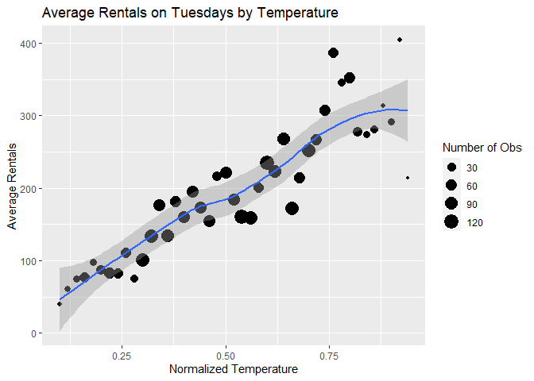

```r
tempAvg <- dayData %>%
  group_by(temp) %>%
  summarize(avgRentals = mean(cnt), n = n())

corrTemp <- cor(tempAvg$temp, tempAvg$avgRentals)

ggplot(tempAvg, aes(x = temp, y = avgRentals)) +
  geom_point(aes(size = n)) +
  geom_smooth() +
  labs(title = paste0("Average Rentals on ", paste0(params$day, "s"), " by Temperature"),
       x = "Normalized Temperature",
       y = "Average Rentals") +
  scale_size_continuous(name = "Number of Obs")
```

The correlation between temperature and average rentals is 0.9036214.

Be careful, correlation measures straight line relationships, so if the plot above shows a curved relationship, correlation may not be a useful measure.

### Felt Temperature

Create a scatter plot to investigate the relationship between felt temperature and average rentals on Tuesdays. Fit a line through the points to get a basic idea of how average rentals changes with felt temperature.

The size of the dots represents the number of observations at each felt temperature.

As already noted, it does not make much sense to keep *atemp* if *temp* and *hum* will be in the model, so I eliminated *atemp* from the model.

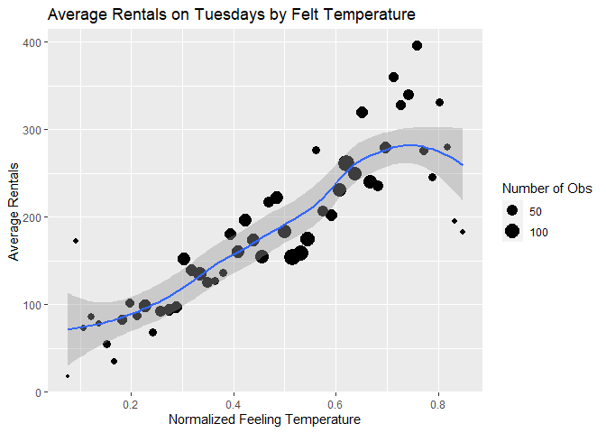

```r
atempAvg <- dayData %>%
  group_by(atemp) %>%
  summarize(avgRentals = mean(cnt), n = n())

corrATemp <- cor(atempAvg$atemp, atempAvg$avgRentals)

ggplot(atempAvg, aes(x = atemp, y = avgRentals)) +
  geom_point(aes(size = n)) +
  geom_smooth() +
  labs(title = paste0("Average Rentals on ", paste0(params$day, "s"), " by Felt Temperature"),
       x = "Normalized Feeling Temperature",
       y = "Average Rentals") +
  scale_size_continuous(name = "Number of Obs")
```

The correlation between felt temperature and average rentals is 0.861061.

Be careful, correlation measures straight line relationships, so if the plot above shows a curved relationship, correlation may not be a useful measure.

### Humidity

Create a scatter plot to investigate the relationship between humidity and average rentals on Tuesdays. Fit a line through the points to get a basic idea of how average rentals changes with humidity.

The size of the dots represents the number of observations at each humidity level.

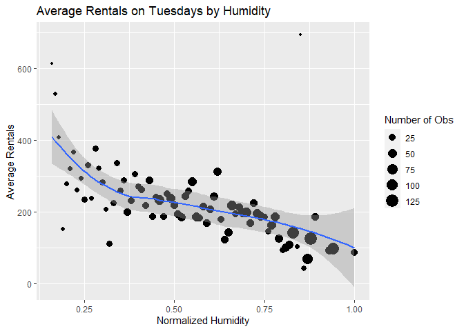

```r
humAvg <- dayData %>%
  group_by(hum) %>%
  summarize(avgRentals = mean(cnt), n = n())

corrHum <- cor(humAvg$hum, humAvg$avgRentals)

ggplot(humAvg, aes(x = hum, y = avgRentals)) +
  geom_point(aes(size = n)) +
  geom_smooth() +
  labs(title = paste0("Average Rentals on ", paste0(params$day, "s"), " by Humidity"),
       x = "Normalized Humidity",
       y = "Average Rentals") +
  scale_size_continuous(name = "Number of Obs")
```

The correlation between humidity and average rentals is -0.55744.

Be careful, correlation measures straight line relationships, so if the plot above shows a curved relationship, correlation may not be a useful measure.

### Wind Speed

Create a scatter plot to investigate the relationship between wind speed and average rentals on Tuesdays. Fit a line through the points to get a basic idea of how average rentals changes with wind speed.

The size of the dots represents the number of observations at each wind speed.

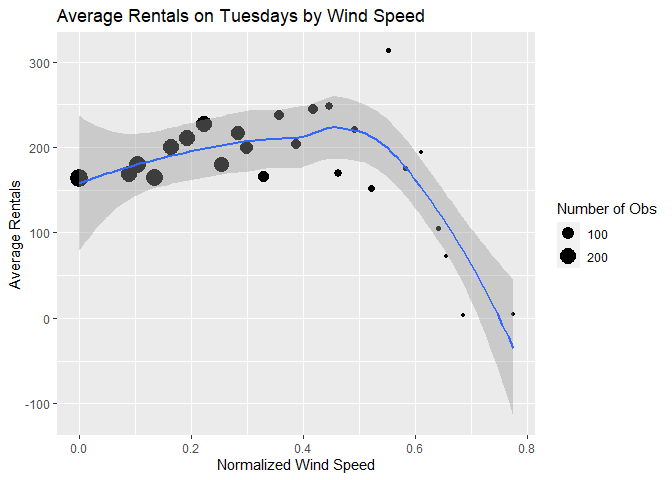

```r
windAvg <- dayData %>%
  group_by(windspeed) %>%
  summarize(avgRentals = mean(cnt), n = n())

corrWind <- cor(windAvg$windspeed, windAvg$avgRentals)

ggplot(windAvg, aes(x = windspeed, y = avgRentals)) +
  geom_point(aes(size = n)) +
  geom_smooth() +
  labs(title = paste0("Average Rentals on ", paste0(params$day, "s"), " by Wind Speed"),
       x = "Normalized Wind Speed",
       y = "Average Rentals") +
  scale_size_continuous(name = "Number of Obs")
```

The correlation between wind speed and average rentals is -0.4214456.

Be careful, correlation measures straight line relationships, so if the plot above shows a curved relationship, correlation may not be a useful measure.

## Categorical Predictors

### Helper Function

Create a helper function to display basic numeric summaries for a given grouping variable.

```r
getSum <- function(varName, colName){

  sum <- dayData %>%
    group_by(dayData[[varName]]) %>%
    summarize(min = min(cnt),
              Q1 = quantile(cnt, probs = c(.25), names = FALSE),
              median = median(cnt),
              mean = mean(cnt),
              Q3 = quantile(cnt, probs = c(.75), names = FALSE),
              max = max(cnt),
              obs = n())

  output <- sum %>%
    kable(col.names = c(colName,
                        "Minimum",
                        "1st Quartile",
                        "Median",
                        "Mean",
                        "3rd Quartile",
                        "Maximum",
                        "Number of Observations"))

  return(output)

}
```

### Season

Explore how bike rentals on Tuesdays change with the seasons using a basic numeric summary and a boxplot. The numeric summary gives you an idea of center and spread. So does the boxplot, but it is better for identifying outliers.

It does not make much sense to keep both *season* and *mnth* in the model, so I decided to eliminate *season*.

```r
getSum(varName = "season", colName = "Season")
```

| Season | Minimum | 1st Quartile | Median | Mean | 3rd Quartile | Maximum | Number of Observations |
| --- | --- | --- | --- | --- | --- | --- | --- |
| winter | 1 | 23.5 | 85.0 | 122.2644 | 170.00 | 801 | 571 |
| spring | 1 | 35.0 | 159.5 | 201.0401 | 285.25 | 850 | 624 |
| summer | 1 | 57.0 | 192.0 | 236.0355 | 328.00 | 970 | 647 |
| fall | 1 | 40.0 | 157.0 | 198.2520 | 289.00 | 967 | 611 |

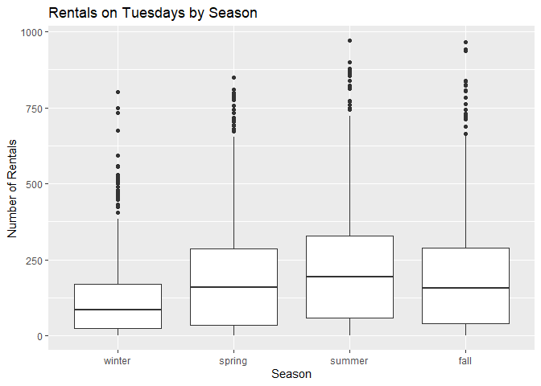

```r
ggplot(dayData, aes(x = season, y = cnt)) +
  geom_boxplot() +
  labs(title = paste0("Rentals on ", paste0(params$day, "s"), " by Season"),
       x = "Season",
       y = "Number of Rentals")
```

### Year

Looking at total rentals each year gives us some idea of the long term trend in bike rentals on Tuesdays. It would be helpful to have data from more years, though.

```r
yearSum <- dayData %>%
  group_by(yr) %>%
  summarize(totalRentals = sum(cnt))

yearSum %>% kable(col.names = c("Year", "Total Rentals"))
```

| Year | Total Rentals |
| --- | --- |
| 2011 | 180338 |
| 2012 | 288771 |

### Month

Explore how bike rentals on Tuesdays change depending on the month using a basic numeric summary and a boxplot. The numeric summary gives you an idea of center and spread. So does the boxplot, but it is better for identifying outliers.

As already noted, it is probably not worth including *mnth* and *season* in the model, so *season* has been eliminated.

```r
getSum(varName = "mnth", colName = "Month")
```

| Month | Minimum | 1st Quartile | Median | Mean | 3rd Quartile | Maximum | Number of Observations |
| --- | --- | --- | --- | --- | --- | --- | --- |
| jan | 1 | 27.25 | 83.0 | 116.7172 | 168.75 | 559 | 198 |
| feb | 1 | 29.50 | 86.0 | 123.4536 | 172.00 | 559 | 183 |
| mar | 1 | 25.50 | 104.0 | 149.6093 | 220.50 | 801 | 215 |
| apr | 1 | 29.50 | 132.0 | 189.8281 | 277.50 | 800 | 192 |
| may | 2 | 37.50 | 175.0 | 209.3750 | 286.25 | 785 | 240 |
| jun | 2 | 54.00 | 189.5 | 236.7031 | 328.50 | 900 | 192 |
| jul | 2 | 72.00 | 200.0 | 243.5093 | 334.00 | 877 | 216 |
| aug | 3 | 63.00 | 208.5 | 247.1019 | 343.25 | 878 | 216 |
| sep | 1 | 45.50 | 172.0 | 217.1518 | 304.00 | 970 | 191 |
| oct | 1 | 60.50 | 180.0 | 224.5369 | 317.50 | 943 | 203 |
| nov | 1 | 27.50 | 136.5 | 168.3426 | 242.00 | 665 | 216 |
| dec | 1 | 24.50 | 107.0 | 155.5288 | 242.00 | 743 | 191 |

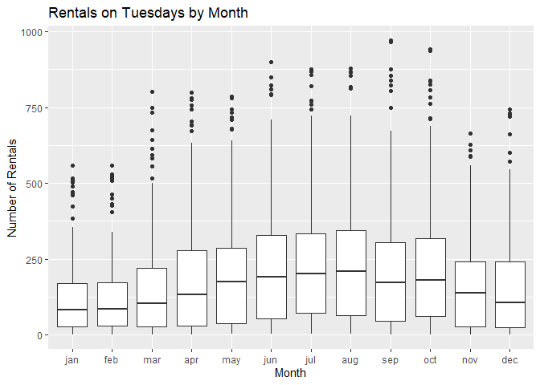

```r
ggplot(dayData, aes(x = mnth, y = cnt)) +
  geom_boxplot() +
  labs(title = paste0("Rentals on ", paste0(params$day, "s"), " by Month"),
       x = "Month",
       y = "Number of Rentals")
```

### Holiday

Explore how bike rentals change depending on whether the Tuesday in question is a holiday using a basic numeric summary and a boxplot. The numeric summary gives you an idea of center and spread. So does the boxplot, but it is better for identifying outliers.

Note: There are no holidays on Saturday or Sunday because the holiday data has been extracted from the [Washington D.C. HR department’s holiday schedule](https://dchr.dc.gov/page/holiday-schedules), which only lists holidays that fall during the work week. Accordingly, I have left the *holiday* variable out of the models for Saturday and Sunday.

```r
getSum(varName = "holiday", colName = "Holiday")
```

| Holiday | Minimum | 1st Quartile | Median | Mean | 3rd Quartile | Maximum | Number of Observations |
| --- | --- | --- | --- | --- | --- | --- | --- |
| no | 1 | 36 | 149 | 192.63210 | 277 | 970 | 2430 |
| yes | 1 | 12 | 32 | 44.04348 | 68 | 126 | 23 |

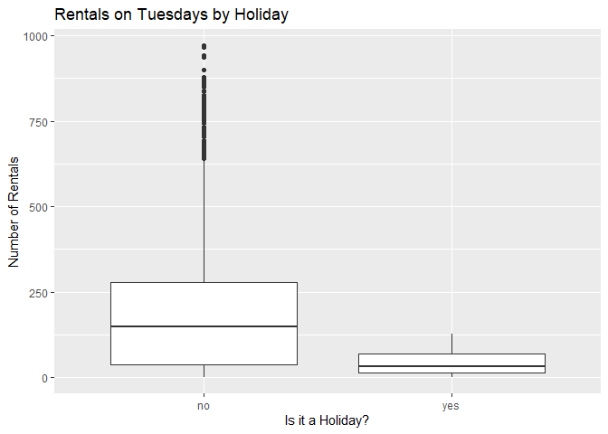

```r
ggplot(dayData, aes(x = holiday, y = cnt)) +
  geom_boxplot() +
  labs(title = paste0("Rentals on ", paste0(params$day, "s"), " by Holiday"),
       x = "Is it a Holiday?",
       y = "Number of Rentals")
```

### Working Day

Explore how bike rentals change depending on whether the day in question is a working day using a basic numeric summary and a boxplot. The numeric summary gives you an idea of center and spread. So does the boxplot, but it is better for identifying outliers.

Working days are neither weekends nor holidays. I decided not to keep this variable in the model because it wouldn’t make much sense in the reports for Saturday and Sunday.

```r
getSum(varName = "workingday", colName = "Working Day")
```

| Working Day | Minimum | 1st Quartile | Median | Mean | 3rd Quartile | Maximum | Number of Observations |
| --- | --- | --- | --- | --- | --- | --- | --- |
| no | 1 | 12 | 32 | 44.04348 | 68 | 126 | 23 |
| yes | 1 | 36 | 149 | 192.63210 | 277 | 970 | 2430 |

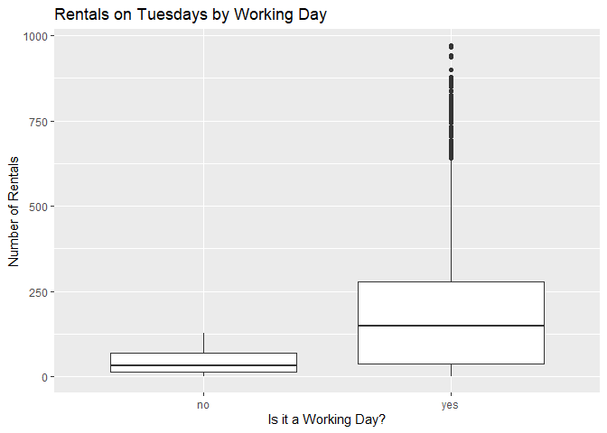

```r
ggplot(dayData, aes(x = workingday, y = cnt)) +
  geom_boxplot() +
  labs(title = paste0("Rentals on ", paste0(params$day, "s"), " by Working Day"),
       x = "Is it a Working Day?",
       y = "Number of Rentals")
```

### Weather Condition

Explore how bike rentals on Tuesdays change depending on the weather using a basic numeric summary and a boxplot. The numeric summary gives you an idea of center and spread. So does the boxplot, but it is better for identifying outliers.

```r
getSum(varName = "weathersit", colName = "Weather Condition")
```

| Weather Condition | Minimum | 1st Quartile | Median | Mean | 3rd Quartile | Maximum | Number of Observations |
| --- | --- | --- | --- | --- | --- | --- | --- |
| pleasant | 1 | 52.25 | 174.5 | 214.8364 | 303.75 | 970 | 1522 |
| less pleasant | 1 | 28.00 | 123.5 | 164.7133 | 238.75 | 868 | 694 |
| even less pleasant | 1 | 20.00 | 66.0 | 117.3713 | 147.00 | 819 | 237 |

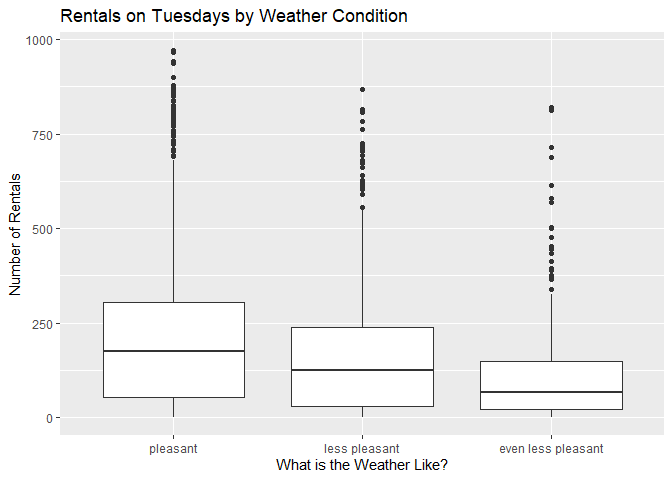

```r
ggplot(dayData, aes(x = weathersit, y = cnt)) +
  geom_boxplot() +
  labs(title = paste0("Rentals on ", paste0(params$day, "s"), " by Weather Condition"),
       x = "What is the Weather Like?",
       y = "Number of Rentals")
```

# Train Models

After exploring the data, I created two models, a non-ensemble tree and a boosted tree.

## Split Data

Split the data into a training set and a test set. The training set is used to build the models, and the test set is used to evaluate them.

```r
set.seed(123)
trainIndex <- createDataPartition(dayData$cnt, p = .7, list = FALSE)

train <- dayData[trainIndex,]
test <- dayData[-trainIndex,]
```

## Non-Ensemble Tree

### Training

Fit a non-ensemble tree model.

#### Tree Models

Tree models split each predictor space into regions and make a different prediction for each region. For example, suppose we are interested in predicting life expectancy based on exercise habits. We might split the predictor space into **exercises less than one hour a week** and **exercises at least one hour a week** and then predict that people in the second group live longer.

How do we decide whether to split at one hour, one and a half hours, two hours, etc? This decision is made using a method called “Recursive Binary Splitting”, which we don’t have to worry about too much because the *caret* package does it for us.

Ensemble tree models fit lots of trees and then average their results. Here I have created a basic non-ensemble tree to model bicycle rentals.

#### Tuning Parameter

This model has one “tuning parameter” called *cp*. *cp* stands for “Complexity Parameter”, and it controls the number of “nodes” that the tree has.

The life expectancy example above has two terminal nodes: **less than one hour** and **at least one hour**. We could complicate the example by adding additional nodes. For instance, we could divide the group **less than one hour** into two subgroups: **less than half an hour** and **greater than half an hour but less than one hour**. And we could divide **at least one hour a week** into **less than two hours but at least one hour** and **greater than two hours**.

Sometimes increasing the number of nodes makes your model better, but sometimes it makes it worse. There are lots of different methods for picking the best number of nodes. For the bicycle rental model, I used a method called “Leave One Out Cross Validation”.

*LOOCV* works by removing an observation from the data set, using the rest of the data to create a model, and then seeing how well that model does at predicting the observation that was left out. This process is repeated for every observation, and the results are combined.

If we want to compare two different values of *cp*, we will go through the *LOOCV* process twice and compare the results. In this way, we can test different values of *cp* to see which one performs best.

I used the *caret* package to test 10 different values of *cp*.

#### Formula

The formula that is used to build the models is below. As previously mentioned, *holiday* will be dropped from the models for Saturday and Sunday, but kept in the models for weekdays.

```r
if(params$day == "Saturday" | params$day == "Sunday"){
  form <- formula(cnt ~ yr + mnth + hr + temp + hum + windspeed, showEnv = FALSE)
} else if(params$day %in% c("Monday", "Tuesday", "Wednesday", "Thursday", "Friday")){
  form <- formula(cnt ~ yr + mnth + hr + holiday + temp + hum + windspeed, showEnv = FALSE)
} else{
  stop("error")
}

form
```

```
## cnt ~ yr + mnth + hr + holiday + temp + hum + windspeed
## <environment: 0x000002aad51499d8>
```

#### Create the Model

Train the non-ensemble tree model using the above formula.

```r
set.seed(123)
tree <- train(form,
              data = train,
              method = "rpart",
              trControl = trainControl(method = "LOOCV"),
              tuneLength = 10)
```

### Model Information

My final non-ensemble tree model uses a *cp* of 0.0117696. Its root mean square error on the training set is 95.5422367.

More information about this model is below.

```r
tree
```

```
## CART
##
## 1719 samples
##    7 predictor
##
## No pre-processing
## Resampling: Leave-One-Out Cross-Validation
## Summary of sample sizes: 1718, 1718, 1718, 1718, 1718, 1718, ...
## Resampling results across tuning parameters:
##
##   cp          RMSE       Rsquared
##   0.01176962   95.54224  0.735780760
##   0.01280478   97.17754  0.726516805
##   0.01716169  102.48056  0.696130737
##   0.02307597  106.45261  0.672225709
##   0.02434265  111.38036  0.642278565
##   0.02900421  117.88931  0.599765135
##   0.03029094  119.63766  0.585999875
##   0.05575980  126.51914  0.536961905
##   0.08353242  165.25591  0.230081400
##   0.31082120  190.87334  0.001488831
##   MAE
##    66.12993
##    68.77486
##    73.90667
##    74.37923
##    77.43030
##    80.33408
##    83.31669
##    89.19741
##   118.32685
##   164.33395
##
## RMSE was used to select the
##  optimal model using the
##  smallest value.
## The final value used for the model
##  was cp = 0.01176962.
```

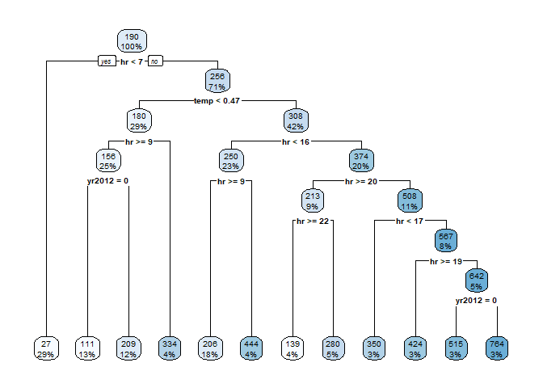

```r
rpart.plot(tree$finalModel)
```

## Boosted Tree

### Training

#### Boosted Tree Models

Boosted trees are another type of tree model. “Boosting” works by fitting a series of trees, each of which is a modified version of the previous tree. The idea is to hone in on the best model.

#### Tuning Paremeters

Four tuning parameters are involved:  
- *n.trees*: number of boosting iterations  
- *interaction.depth*: maximum tree depth  
- *shrinkage*: how strongly each subsequent tree is influenced by the previous tree  
- *n.minobsinnode*: minimum terminal node size

Values for the tuning parameters are found using Cross Validation. Cross Validation works by splitting the data into groups called “folds”. One fold is left out, the rest are used to create a model, and then that model is tested on the fold that was left out. This process is repeated for each fold, and the results are combined. It should be clear that *LOOCV* is just *CV* with the number of folds equal to the number of observations.

I used the *caret* package to test 81 different combinations of tuning parameters.

#### Create the Model

Train the boosted tree model using the same formula as above.

```r
tuneGr <- expand.grid(n.trees = seq(from = 50, to = 150, by = 50),
                     interaction.depth = 1:3,
                     shrinkage = seq(from = .05, to = .15, by = .05),
                     n.minobsinnode = 9:11)

set.seed(123)
boostTree <- train(form,
                   data = train,
                   method = "gbm",
                   trControl = trainControl(method = "cv", number = 10),
                   tuneGrid = tuneGr,
                   verbose = FALSE)
```

### Model Information

My final boosted tree model uses the following tuning parameters:

- *n.trees*: 150
- *interaction.depth*: 3
- *shrinkage*: 0.15
- *n.minobsinnode*: 9

Its root mean square error on the training set is 52.8398785.

More information about this model is below.

```r
boostTree
```

```
## Stochastic Gradient Boosting
##
## 1719 samples
##    7 predictor
##
## No pre-processing
## Resampling: Cross-Validated (10 fold)
## Summary of sample sizes: 1547, 1546, 1547, 1547, 1547, 1548, ...
## Resampling results across tuning parameters:
##
##   shrinkage  interaction.depth
##   0.05       1
##   0.05       1
##   0.05       1
##   0.05       1
##   0.05       1
##   0.05       1
##   0.05       1
##   0.05       1
##   0.05       1
##   0.05       2
##   0.05       2
##   0.05       2
##   0.05       2
##   0.05       2
##   0.05       2
##   0.05       2
##   0.05       2
##   0.05       2
##   0.05       3
##   0.05       3
##   0.05       3
##   0.05       3
##   0.05       3
##   0.05       3
##   0.05       3
##   0.05       3
##   0.05       3
##   0.10       1
##   0.10       1
```

[output cut: 208 more lines]

```
##   0.9127564   36.06401
##   0.9196179   34.26809
##   0.8922060   41.93266
##   0.9125157   36.27501
##   0.9184500   34.56696
##   0.8914442   42.03256
##   0.9101148   36.86201
##   0.9151441   35.27858
##
## RMSE was used to select the
##  optimal model using the
##  smallest value.
## The final values used for the
##  shrinkage = 0.15 and n.minobsinnode
##  = 9.
```

## Multiple Linear Regression

### Training

#### Create the Model

```r
mlr <- lm(form, data = train)
```

# Test Models

I tested the models on the test set and selected the model that performed best.

Performance was measured using Root Mean Square Error, which is a measure of how close the model gets to correctly predicting the test data. The RMSE for each model is displayed below.

```r
treePreds <- predict(tree, test)
treeRMSE <- postResample(treePreds, test$cnt)[1]

boostPreds <- predict(boostTree, test)
boostRMSE <- postResample(boostPreds, test$cnt)[1]

mlrPreds <- predict(mlr, test)
mlrRMSE <- postResample(mlrPreds, test$cnt)[1]

modelPerformance <- data.frame(model = c("Non-Ensemble Tree", "Boosted Tree", "MLR"),
                               trainRMSE = c(min(tree$results$RMSE), min(boostTree$results$RMSE),
                                             summary(mlr)$sigma),
                               testRMSE = c(treeRMSE, boostRMSE, mlrRMSE))

modelPerformance %>% kable(col.names = c("Model", "Train RMSE", "Test RMSE"))
```

| Model | Train RMSE | Test RMSE |
| --- | --- | --- |
| Non-Ensemble Tree | 95.54224 | 98.39942 |
| Boosted Tree | 52.83988 | 54.12700 |
| MLR | 150.38621 | 157.30329 |

# Best Model

```r
best <- modelPerformance %>% filter(testRMSE == min(testRMSE))
worst <- modelPerformance %>% filter(testRMSE == max(testRMSE))
```

The boosted tree performs best as judged by RMSE on the test set.

The boosted tree model is saved to the `final` object below.

```r
if(best$model == "Non-Ensemble Tree"){
  final <- tree
  final
} else if(best$model == "Boosted Tree"){
  final <- boostTree
  final$finalModel
} else if(best$model == "MLR"){
  final <- mlr
  final
} else{
  stop("Error")
}
```

```
## A gradient boosted model with gaussian loss function.
## 150 iterations were performed.
## There were 17 predictors of which 16 had non-zero influence.
```